# Hands On-1

Regina Rodriguez Durant (regina.rodriguezdurant01@estudiant.upf.edu)

Last update: 02 febrero, 2026

This practical focuses on data wrangling, exploratory data analysis, visualization, and critical comparison with published results using real biomedical data.

We will work with the publication  
[**Proteomic and Metabolomic Characterization of COVID-19 Patient Sera**](https://www.sciencedirect.com/science/article/pii/S0092867420306279)

# Exercise 1

Download and load Supplementary Table 1 (“Additional Demographical and Baseline Characteristics of COVID-19 Patients and Control Groups”) from the supplementary materials of the publication.

```r
data <- read_csv("data/Table_S1. - Clinical_information.csv",
                 na = c("/", ""),
                 locale = locale(decimal_mark = ","),
                 show_col_types = FALSE)
```

#Names of the variables

```r
data <- data %>%
rename(
Group = `Group d`,
Sex   = `Sex g`,
Age   = `Age (year)`,
BMI   = `BMI h`
) %>%
mutate(
Group = as.factor(Group),
Sex   = as.factor(Sex)
)
```

```r
str(data)
```

```
## tibble [118 × 31] (S3: tbl_df/tbl/data.frame)
##  $ Patient ID a                       : chr [1:118] "XG1" "XG2" "XG3" "XG4" ...
##  $ Proteomics                         : chr [1:118] "Yes" "Yes" "Yes" "Yes" ...
##  $ MS ID b                            : chr [1:118] "F1_126" "F1_127N" "F1_127C" "F2_126" ...
##  $ MSRep ID c                         : chr [1:118] "F1_133N" NA NA NA ...
##  $ Group                              : Factor w/ 4 levels "0","1","2","3": 3 3 3 3 3 3 3 3 3 3 ...
##  $ COVID-19 patients corhort          : chr [1:118] "Training (C1)" "Training (C1)" "Training (C1)" "Training (C1)" ...
##  $ Metabolomics analysis              : chr [1:118] "Yes" "Yes" "Yes" "Yes" ...
##  $ Metabolomics ID e                  : chr [1:118] "PT1" "PT2" "PT3" "PT4" ...
##  $ Onset date f                       : chr [1:118] "24/1/2020" "31/1/2020" "2/2/2020" "26/1/2020" ...
##  $ Admission date                     : chr [1:118] "25/1/2020" "2/2/2020" "4/2/2020" "1/2/2020" ...
##  $ Date of progression to severe state: chr [1:118] NA NA NA NA ...
##  $ Sampling date for metabolomics     : chr [1:118] "26/1/2020" "3/2/2020" "5/2/2020" "2/2/2020" ...
##  $ Sampling date for proteomics       : chr [1:118] "5/2/2020" "12/2/2020" "5/2/2020" "2/2/2020" ...
##  $ Discharge Date                     : chr [1:118] "14/2/2020" "12/2/2020" "3/3/2020" "10/2/2020" ...
```

[output cut: 17 more lines]

```r
summary(data)
```

```
##  Patient ID a        Proteomics          MS ID b           MSRep ID c
##  Length:118         Length:118         Length:118         Length:118
##  Class :character   Class :character   Class :character   Class :character
##  Mode  :character   Mode  :character   Mode  :character   Mode  :character
##
##
##
##
##  Group  COVID-19 patients corhort Metabolomics analysis Metabolomics ID e
##  0:28   Length:118                Length:118            Length:118
##  1:25   Class :character          Class :character      Class :character
##  2:37   Mode  :character          Mode  :character      Mode  :character
##  3:28
##
##
##
##  Onset date f       Admission date     Date of progression to severe state
##  Length:118         Length:118         Length:118
##  Class :character   Class :character   Class :character
##  Mode  :character   Mode  :character   Mode  :character
##
##
##
##
##  Sampling date for metabolomics Sampling date for proteomics Discharge Date
##  Length:118                     Length:118                   Length:118
##  Class :character               Class :character             Class :character
##  Mode  :character               Mode  :character             Mode  :character
##
##
##
##
##  Sex         Age             BMI        Test date...18     WBC count, ×109/L
##  0:41   Min.   :18.00   Min.   :18.94   Length:118         Min.   : 1.900
##  1:77   1st Qu.:38.00   1st Qu.:22.49   Class :character   1st Qu.: 5.000
##         Median :47.00   Median :24.43   Mode  :character   Median : 6.100
##         Mean   :47.42   Mean   :24.52                      Mean   : 6.924
##         3rd Qu.:56.00   3rd Qu.:26.64                      3rd Qu.: 7.750
##         Max.   :77.00   Max.   :32.87                      Max.   :24.200
##                         NA's   :8                          NA's   :28
```

[output cut: 17 more lines]

```
##  Min.   :  9.00   Min.   :  3.400   Min.   :  0.800   Min.   :  4.00
##  1st Qu.: 18.25   1st Qu.:  9.675   1st Qu.:  3.125   1st Qu.: 66.00
##  Median : 28.50   Median : 13.400   Median :  4.750   Median : 76.50
##  Mean   : 39.59   Mean   : 20.307   Mean   :  9.022   Mean   : 82.26
##  3rd Qu.: 48.75   3rd Qu.: 18.800   3rd Qu.:  6.650   3rd Qu.: 89.00
##  Max.   :264.00   Max.   :403.400   Max.   :254.400   Max.   :335.00
##  NA's   :28       NA's   :28        NA's   :28        NA's   :28
##  Glucose, mmol/L
##  Min.   : 3.650
##  1st Qu.: 5.433
##  Median : 6.260
##  Mean   : 7.484
##  3rd Qu.: 8.095
##  Max.   :25.630
##  NA's   :28
```

## Exercise 1.1

#Reproduce Table 1 from the manuscript using the supplementary data. Match the reported summary statistics as closely as possible.

#Briefly discuss any discrepancies between your results and the published table, and provide possible explanations.

```r
data <- data %>%
  mutate(
    BMI = as.numeric(gsub(",", ".", BMI)),
    across(where(is.character) & contains("count") | contains("CRP") | contains("BIL"),
           ~as.numeric(gsub(",", ".", .))),
    Group = as.factor(Group),
    Sex = as.factor(Sex)
  )
table1 <- data %>%
  group_by(Group) %>%
  summarise(
    N = n(),
    Age_mean = round(mean(Age, na.rm = TRUE), 1),
    Age_sd = round(sd(Age, na.rm = TRUE), 1),
    BMI_mean = round(mean(BMI, na.rm = TRUE), 1),
    BMI_sd = round(sd(BMI, na.rm = TRUE), 1),
    Female_pct = round(mean(Sex == "1", na.rm = TRUE) * 100, 1),  # Sex coded as 0/1
    .groups = "drop"
  )

kable(table1, format = "html", digits = 1,
      caption = "Table 1: Summary statistics by group") %>%
  kable_styling(bootstrap_options = c("striped", "hover"))
```

Table 1: Summary statistics by group

| Group | N | Age_mean | Age_sd | BMI_mean | BMI_sd | Female_pct |
| --- | --- | --- | --- | --- | --- | --- |
| 0 | 28 | 44.4 | 8.3 | 24.4 | 2.7 | 75.0 |
| 1 | 25 | 49.2 | 14.0 | 23.5 | 2.7 | 68.0 |
| 2 | 37 | 42.9 | 12.5 | 24.5 | 3.2 | 62.2 |
| 3 | 28 | 54.8 | 12.8 | 25.5 | 2.5 | 57.1 |

## Exercise 1.2

#Perform an exploratory data analysis (EDA) of the dataset. At a minimum, include:

#- Descriptive statistics for key variables  
#- Appropriate visualizations (e.g. distributions, group comparisons)  
#- A brief written summary of notable patterns, anomalies, or data quality issues

```r
summary(data)
```

```
##  Patient ID a        Proteomics          MS ID b           MSRep ID c
##  Length:118         Length:118         Length:118         Length:118
##  Class :character   Class :character   Class :character   Class :character
##  Mode  :character   Mode  :character   Mode  :character   Mode  :character
##
##
##
##
##  Group  COVID-19 patients corhort Metabolomics analysis Metabolomics ID e
##  0:28   Length:118                Length:118            Length:118
##  1:25   Class :character          Class :character      Class :character
##  2:37   Mode  :character          Mode  :character      Mode  :character
##  3:28
##
##
##
##  Onset date f       Admission date     Date of progression to severe state
##  Length:118         Length:118         Length:118
##  Class :character   Class :character   Class :character
##  Mode  :character   Mode  :character   Mode  :character
##
##
##
##
##  Sampling date for metabolomics Sampling date for proteomics Discharge Date
##  Length:118                     Length:118                   Length:118
##  Class :character               Class :character             Class :character
##  Mode  :character               Mode  :character             Mode  :character
##
##
##
##
##  Sex         Age             BMI        Test date...18     WBC count, ×109/L
##  0:41   Min.   :18.00   Min.   :18.94   Length:118         Min.   : 1.900
##  1:77   1st Qu.:38.00   1st Qu.:22.49   Class :character   1st Qu.: 5.000
##         Median :47.00   Median :24.43   Mode  :character   Median : 6.100
##         Mean   :47.42   Mean   :24.52                      Mean   : 6.924
##         3rd Qu.:56.00   3rd Qu.:26.64                      3rd Qu.: 7.750
##         Max.   :77.00   Max.   :32.87                      Max.   :24.200
##                         NA's   :8                          NA's   :28
```

[output cut: 17 more lines]

```
##  Min.   :  9.00   Min.   :  3.400   Min.   :  0.800   Min.   :  4.00
##  1st Qu.: 18.25   1st Qu.:  9.675   1st Qu.:  3.125   1st Qu.: 66.00
##  Median : 28.50   Median : 13.400   Median :  4.750   Median : 76.50
##  Mean   : 39.59   Mean   : 20.307   Mean   :  9.022   Mean   : 82.26
##  3rd Qu.: 48.75   3rd Qu.: 18.800   3rd Qu.:  6.650   3rd Qu.: 89.00
##  Max.   :264.00   Max.   :403.400   Max.   :254.400   Max.   :335.00
##  NA's   :28       NA's   :28        NA's   :28        NA's   :28
##  Glucose, mmol/L
##  Min.   : 3.650
##  1st Qu.: 5.433
##  Median : 6.260
##  Mean   : 7.484
##  3rd Qu.: 8.095
##  Max.   :25.630
##  NA's   :28
```

```r
# Missing Data Table
missing_pct <- colSums(is.na(data)) / nrow(data) * 100
missing_df <- data.frame(
  Variable = names(missing_pct),
  Percent_NA = round(missing_pct, 1)
) %>%
  arrange(desc(Percent_NA)) %>%
  filter(Percent_NA > 0)

kable(missing_df, digits = 1,
      caption = "Variables with Missing Data (%)") %>%
  kable_styling(bootstrap_options = c("striped", "hover"))
```

Variables with Missing Data (%)

|  | Variable | Percent_NA |
| --- | --- | --- |
| MSRep ID c | MSRep ID c | 94.9 |
| Date of progression to severe state | Date of progression to severe state | 76.3 |
| COVID-19 patients corhort | COVID-19 patients corhort | 49.2 |
| Sampling date for proteomics | Sampling date for proteomics | 49.2 |
| Onset date f | Onset date f | 44.9 |
| Sampling date for metabolomics | Sampling date for metabolomics | 44.9 |
| Discharge Date | Discharge Date | 44.9 |
| CRP i, mg/L | CRP i, mg/L | 28.0 |
| Admission date | Admission date | 23.7 |
| Test date…10 | Test date…18 | 23.7 |
| WBC count, ×109/L | WBC count, ×109/L | 23.7 |
| Lymphocyte count, ×109/L | Lymphocyte count, ×109/L | 23.7 |
| Monocyte count, ×109/L | Monocyte count, ×109/L | 23.7 |
| Platelet count, ×109/L | Platelet count, ×109/L | 23.7 |
| Test date…15 | Test date…23 | 23.7 |
| ALT j, U/L | ALT j, U/L | 23.7 |
| AST k, U/L | AST k, U/L | 23.7 |
| GGT l, U/L | GGT l, U/L | 23.7 |
| TBIL m, μmol/L | TBIL m, μmol/L | 23.7 |
| DBIL n, μmol/L | DBIL n, μmol/L | 23.7 |
| Creatinine, μmol/L | Creatinine, μmol/L | 23.7 |
| Glucose, mmol/L | Glucose, mmol/L | 23.7 |
| MS ID b | MS ID b | 11.0 |
| BMI | BMI | 6.8 |
| Metabolomics ID e | Metabolomics ID e | 2.5 |

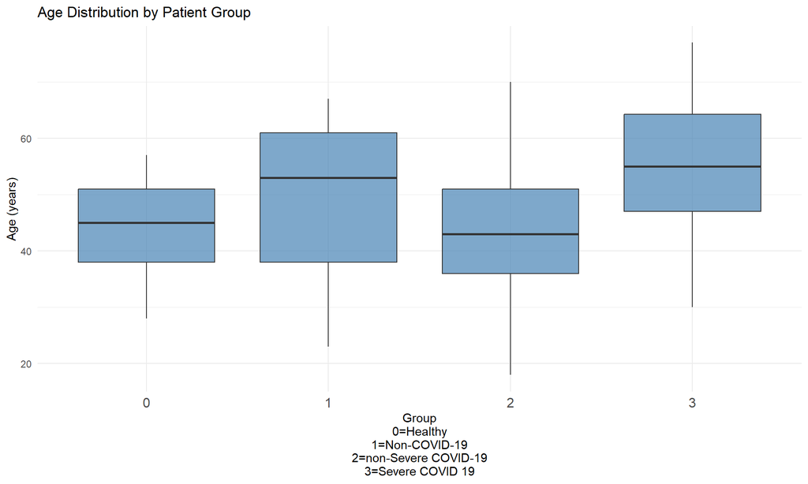

```r
ggplot(data, aes(x = Group, y = Age)) +
  geom_boxplot(fill = "steelblue", alpha = 0.7) +
  labs(x = "Group\n0=Healthy\n1=Non-COVID-19\n2=non-Severe COVID-19\n3=Severe COVID 19",
       y = "Age (years)",
       title = "Age Distribution by Patient Group") +
  theme_minimal() +
  theme(axis.text.x = element_text(size = 12, angle = 0))
```

# Exercise 2

## Exercise 2.1

Reproduce Supplementary Figure 1 using the data without modifying or removing any observations. Use the same variables and groupings as in the original figure.

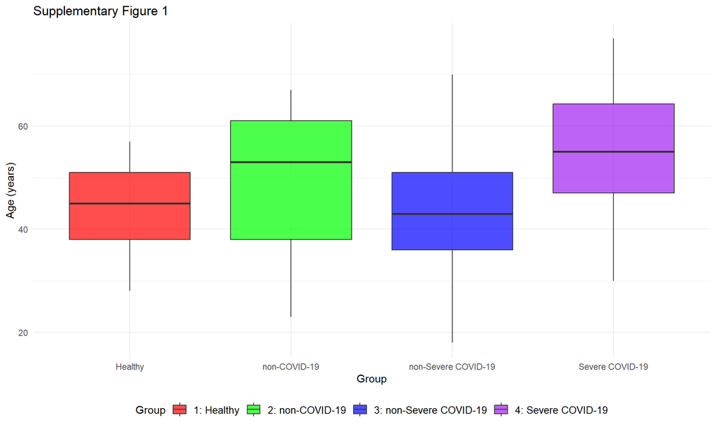

```r
ggplot(data, aes(x = Group, y = Age, fill = Group)) +
  geom_boxplot(alpha = 0.7) +
  labs(x = "Group", y = "Age (years)", title = "Supplementary Figure 1") +
  scale_x_discrete(labels = c("Healthy", "non-COVID-19", "non-Severe COVID-19", "Severe COVID-19")) +
  scale_fill_manual(values = c("red", "green", "blue", "purple"),
                    labels = c("1: Healthy", "2: non-COVID-19", "3: non-Severe COVID-19", "4: Severe COVID-19"),
                    name = "Group") +
  theme_minimal() +
  theme(legend.position = "bottom", legend.text = element_text(size = 10))
```

## Exercise 2.2

Identify and handle outliers using an appropriate and well-justified method (e.g. removal, transformation, or robust statistics).

Reproduce Supplementary Figure 1 after outlier handling and discuss how and why the results change.

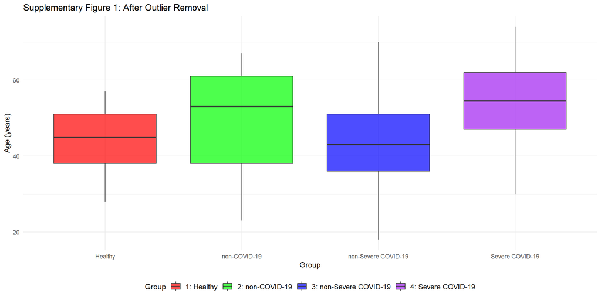

```r
data_no_out <- data %>% filter(Age < quantile(Age, 0.99, na.rm = TRUE))

ggplot(data_no_out, aes(x = Group, y = Age, fill = Group)) +
  geom_boxplot(alpha = 0.7) +
  labs(x = "Group", y = "Age (years)", title = "Supplementary Figure 1: After Outlier Removal") +
  scale_x_discrete(labels = c("Healthy", "non-COVID-19", "non-Severe COVID-19", "Severe COVID-19")) +
  scale_fill_manual(values = c("red", "green", "blue", "purple"),
                    labels = c("1: Healthy", "2: non-COVID-19", "3: non-Severe COVID-19", "4: Severe COVID-19"),
                    name = "Group") +
  theme_minimal() +
  theme(legend.position = "bottom", legend.text = element_text(size = 10))
```